# Individual Assignment 2

Author

Megha Deshmukh 24230928

## Introduction

This assignment focuses on analyzing data related to cyberattacks and their effects on industries. The goal is to explore three datasets: Cyberattack Data, Compliance Data, and Data Breach Data. The aim is to combine these datasets to understand how industries are affected by cyberattacks and security controls effectiveness against breaches together with their resulting data losses. My research will offer guidance to businesses as well as policymakers for enhancing cybersecurity through integrated findings.

#### Dataset 1: [Cyberattack Data](https://www.kaggle.com/datasets/shakirul09/cyber-crimes-dataset).

The dataset provides information about different types of cyberattacks together with the targeted systems’ results after attacks. The database provides information about distinct cyberattack forms and industry targets with data loss measurement data.

#### Dataset 2: [global cybersecurity threats](https://www.kaggle.com/datasets/atharvasoundankar/global-cybersecurity-threats-2015-2024)

The dataset examines security controls together with compliance measures that organizations implement for securing their operations. This database shows how well security controls operate through compliance scoring which aids organizations in defending themselves from cyber threats.

The dataset contains comprehensive information about recent data breaches which shows their origins together with the business sectors they targeted and the number of people affected. The data show different breach types, breach lengths and which industries experience the greatest risk of lost data.

#### GitHub Repository and Version Control [Git_Link](https://github.com/deshmukhmegh-cyber/R-Programming/tree/assignment1)

The code has been uploaded to a private GitHub repository with meaningful commits over time. Assignment 1 is in the assignment1 branch, and Assignment 2 is in the feature-branch-assignment2 branch. A brief introductory note is included in the README.md file.

## Flow Digram using mermaid for cyber crime dataset

```
  graph TD;

  A[Start] --> B[Load Libraries]
  B --> C[Read and Clean Data]
  C --> D[Filter & Select Columns]
  D --> E[Merge Datasets]
  E --> F[Perform Data Analysis]
  F --> G[Build GLM & GAM Models]
  G --> H[Visualize Data]
  H --> I1[Plot Attack Severity]
  H --> I2[Plot Industry Impact]
  H --> I3[Bubble Chart of Attacks]
  H --> I4[Bar Chart of Defense Mechanisms]
  I1 --> J[Conclusion]
  I2 --> J
  I3 --> J
  I4 --> J
  J --> K[End]
```

## Loaded necessary libraries

```r
library(tidyverse)
library(dplyr)
library(plotly)
library(formattable)
library(RColorBrewer)
library(data.table)
library(ggplot2)
library(mgcv)
library(parallel)
```

## Data Preparation and Cleaning for Cybersecurity Analysis

This R code loads and examines three cyber security data sets. The first data set contains cyberattack information, such as attack type, industry, severity, and lost data, focused on successful attacks with high loss of data. The second data set consists of data for global cyber security threats, such as types of attacks, countermeasures, and affected industries. The third data set consists of Washington data breaches, such as types of attacks, industries, and number of affected users. Suitable columns are selected and renamed for similarity across datasets.

```r
# Read only necessary columns
file_path1 <- "/Users/meghadeshmukh/Desktop/R_Assignment/cybersecurity_large_synthesized_data.csv"
file_path2 <-"/Users/meghadeshmukh/Desktop/R_Assignment/Global_Cybersecurity_Threats_2015-2024.csv"
file_path3 <-"/Users/meghadeshmukh/Desktop/R_Assignment/Data_Breach_Notifications_Affecting_Washington_Residents__Personal_Information_Breakdown_.csv"

dataset1 <- fread(file_path1, select = c("attack_type", "industry", "attack_severity", "security_tools_used","data_compromised_GB","location","outcome"))

dataset2 <- fread(file_path2, select = c("Attack Type","Defense Mechanism Used","Target Industry","Number of Affected Users", "Country" ))
dataset2 <- dataset2 %>%
  rename(
    attack_type = "Attack Type",
    defence_mechanism_used = "Defense Mechanism Used",
    target_industry = "Target Industry"
  )

dataset3 <- fread(file_path3, select = c("CyberattackType","IndustryType","WashingtoniansAffected", "Year", "WashingtoniansAffectedRange", "BreachLifecycleRange", "EntityState","DateSubmitted","DateStart","DateEnd"))
dataset3 <- dataset3 %>%
  rename(
    attack_type = "CyberattackType",
    no_affected_user="WashingtoniansAffected"
  )

filtered_dataset1 <- dataset1 %>%
  filter(outcome == "Success"  & data_compromised_GB > 5) %>%
  select(attack_type, industry, attack_severity,security_tools_used,data_compromised_GB,location)
```

## Data Merging, Cleaning, and Modeling with GLM and GAM for Cybersecurity Analysis

This code merges the filtered cybersecurity data from two datasets and cleans the data by transforming suitable columns to factors. A random 10% subset of the data is used for faster processing, and rows with missing values are removed. Next, a Generalized Linear Model (GLM) is employed to fit to explore the relationship between attack severity, attack type, and data breached. Further, a reduced Generalized Additive Model (GAM) is applied to further examine the data by removing non-significant predictors to enhance model fit. The result of both models is tabulated for interpretation.

```r
# Merge the datasets
dataset1_dataset2 <- filtered_dataset1 %>%
  inner_join(dataset2, by = "attack_type")

# Clean and prepare the data
dataset_sample <- dataset1_dataset2 %>%
  mutate(
    target_industry = as.factor(target_industry),
    defence_mechanism_used = as.factor(defence_mechanism_used),
    attack_type = as.factor(attack_type)
  )

# Sample a smaller subset (e.g., 10% of the data) for faster computation
set.seed(123)
dataset_sample <- dataset1_dataset2 %>% sample_frac(0.1)  # 10% sample

# Clean and prepare the data
dataset_sample <- dataset_sample %>%
  mutate(
    target_industry = as.factor(target_industry),
    defence_mechanism_used = as.factor(defence_mechanism_used),
    attack_type = as.factor(attack_type)
  )

# Remove rows with NAs in important columns
dataset_sample <- dataset_sample %>%
  filter(!is.na(attack_severity) & !is.na(target_industry) & !is.na(defence_mechanism_used) & !is.na(attack_type))
```

## summary output for GLM Model

```r
# Fit the GLM model (removing non-significant predictors)
glm_model <- glm(attack_severity ~ attack_type + data_compromised_GB,
                 data = dataset_sample,
                 family = gaussian())  # Used Gaussian for continuous data
summary(glm_model)
```

```
Call:
glm(formula = attack_severity ~ attack_type + data_compromised_GB,
    family = gaussian(), data = dataset_sample)

Coefficients:
                           Estimate Std. Error t value Pr(>|t|)
(Intercept)               5.568e+00  6.768e-03 822.695  < 2e-16 ***
attack_typeMalware       -1.321e-02  7.373e-03  -1.791 0.073243 .
attack_typePhishing      -2.565e-02  7.228e-03  -3.548 0.000388 ***
attack_typeRansomware    -5.493e-02  7.353e-03  -7.471 7.98e-14 ***
attack_typeSQL Injection -2.613e-02  7.300e-03  -3.580 0.000344 ***
data_compromised_GB      -7.289e-04  8.518e-05  -8.557  < 2e-16 ***
---
Signif. codes:  0 '***' 0.001 '**' 0.01 '*' 0.05 '.' 0.1 ' ' 1

(Dispersion parameter for gaussian family taken to be 8.231815)

    Null deviance: 12398717  on 1506066  degrees of freedom
Residual deviance: 12397615  on 1506061  degrees of freedom
AIC: 7448840

Number of Fisher Scoring iterations: 2
```

## summary output for GAM Model

```r
# Fit the simplified GAM model (removing non-significant smooth terms)
gam_model_simple <- gam(attack_severity ~ s(attack_type, bs = "re", k = 3) +
                                   s(data_compromised_GB, k = 3),
                 data = dataset_sample,
                 family = gaussian())
summary(gam_model_simple)
```

```
Family: gaussian
Link function: identity

Formula:
attack_severity ~ s(attack_type, bs = "re", k = 3) + s(data_compromised_GB,
    k = 3)

Parametric coefficients:
            Estimate Std. Error t value Pr(>|t|)
(Intercept) 5.505672   0.008453   651.3   <2e-16 ***
---
Signif. codes:  0 '***' 0.001 '**' 0.01 '*' 0.05 '.' 0.1 ' ' 1

Approximate significance of smooth terms:
                         edf Ref.df     F p-value
s(attack_type)         3.694  4.000 13.99  <2e-16 ***
s(data_compromised_GB) 1.797  1.959 41.72  <2e-16 ***
---
Signif. codes:  0 '***' 0.001 '**' 0.01 '*' 0.05 '.' 0.1 ' ' 1

R-sq.(adj) =  8.81e-05   Deviance explained = 0.00918%
GCV = 8.2318  Scale est. = 8.2318    n = 1506067
```

## Visualizing the Impact of Cyberattacks by Industry and Defense Mechanisms

This part visually represents the relationship between types of cyberattacks, their severity, and most affected industries. A boxplot shows the distribution of severity by attack type, and a bubble chart shows the number of attacks by industry. A pie chart shows the number of users affected by various types of cyberattacks, such as phishing, malware, and ransomware, by industry. Last, a bar chart is used to compare defense methods’ performance by visualizing the total data compromised versus different types of attack techniques and their respective defense mechanisms. They can be utilized to identify patterns in cyberattacks and their effects.

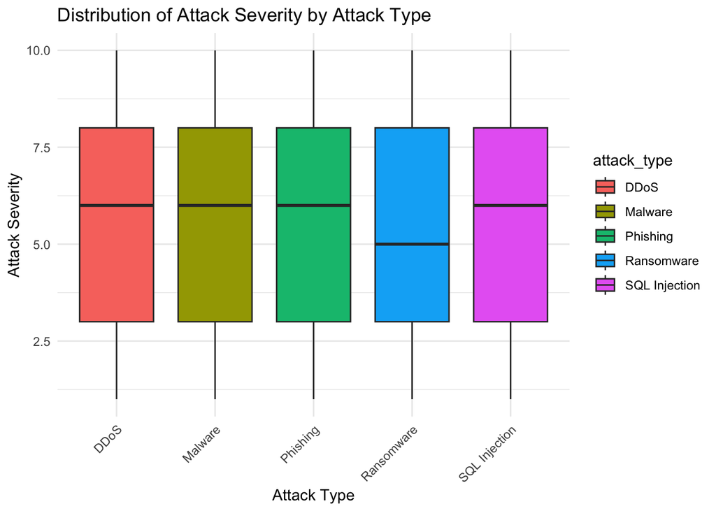

```r
# Ploted boxplot chart for distribution of Attack Severity by Attack Type
ggplot(dataset1_dataset2, aes(x = attack_type, y = attack_severity, fill = attack_type)) +
  geom_boxplot() +
  theme_minimal() +
  labs(title = "Distribution of Attack Severity by Attack Type", x = "Attack Type", y = "Attack Severity") +
  theme(axis.text.x = element_text(angle = 45, hjust = 1))
```

```r
# Create the bubble chart by Groupping the data by target industry and attack type to get the count
country_attack <- dataset1_dataset2 %>%
  group_by(target_industry, attack_type) %>%
  summarise(count = n(), .groups = "drop")

plot_ly(country_attack,
        x = ~target_industry,
        y = ~attack_type,
        size = ~count,
        color = ~attack_type,
        type = 'scatter',
        mode = 'markers',
        hoverinfo = 'text',
        text = ~paste('Attack type: ', attack_type, '<br>Count: ', count),
        marker = list(sizemode = 'diameter', opacity = 0.5)) %>%
  layout(title = "Attack Type by Industry",
         xaxis = list(title = "Most Targeted Industries"),
         yaxis = list(title = "Major Types of Attack"),
         showlegend = FALSE)
```

[interactive chart not shown]

```r
# Plotted pie chart by grouping data to find affected users by IndustryType and CyberattackType
data_grouped <- dataset3 %>%
  group_by(IndustryType, attack_type) %>%
  summarise(total_affected = sum(no_affected_user), .groups = "drop")%>%
  filter(!is.na(total_affected)) %>%
  filter(attack_type %in% c("Phishing", "Malware", "Ransomware","Other"))

plot_ly(data_grouped,
        labels = ~attack_type,
        values = ~total_affected,
        type = "pie",
        textinfo = "label+percent",
        hoverinfo = "label+value+percent",
        marker = list(colorscale = 'Rainbow')) %>%
  layout(title = "Total Affected Users by Industry")
```

[interactive chart not shown]

```r
# Plotted Bar graph by summerizing total Data Compromised by Attack Type and Defense Mechanism used
Impactful_defence_mechanisum <- dataset1_dataset2 %>%
  group_by(attack_type, defence_mechanism_used) %>%
  summarise(total_data = sum(data_compromised_GB), .groups = 'drop')

plot_ly(Impactful_defence_mechanisum,
        x = ~attack_type,
        y = ~total_data,
        color = ~defence_mechanism_used,
        type = 'bar',
        text = ~paste('Defense Mechanism: ', defence_mechanism_used, '<br>Data Compromised: ', total_data, 'GB'),
        hoverinfo = 'text') %>%
  layout(title = "Total Data Compromised by Attack Type and Defense Mechanism used",
         xaxis = list(title = "Attack Type"),
         yaxis = list(title = "Total Data Compromised (GB)"))
```

[interactive chart not shown]